# Ricardo template for Jupyter Notebooks

**Authors:** Gena Gibson

## Intro

This template provides instructions to create reports with a consistent look and feel.

**Before you start, check that you have the latest version of this guidance:**  
Go to the GitHub repository: https://github.com/genagibson/ricardo_template_style  
Download the repository as a zip file, or clone it if you know how to use Git.

### Enable the style sheet

Custom styling for headers, automatic numbering of tables etc is added using a stylesheet.

It provides the formatting for headings, numbered figure captions and tables.

#### Enable for all Notebooks

First, copy the ricardo_stylesheet.css file from the main GitHub repository. It is located here:

```
https://github.com/genagibson/ricardo_template_style/
    styles/
        ricardo_stylesheet.css
```

In terminal, run

```
`pip show notebook`
```

This will show you where the Anaconda installation of the notebook is saved (under 'Location'). Save the custom css file in there, so that the file structure looks like this:

```
anaconda3/lib/python3.7/site-packages/ (or your own path)
    notebook/
        static/
            custom/
                custom.css
```

There will already be a custom.css in the folder: overwrite it.

Close down the notebook entirely, including the terminal, and restart to see the changes.

**NB:** I recommend you enable the stylesheet automatically for **all** of your Notebooks. There are other functions that will be introduced later, which rely on the Ricardo stylesheet to work.

If you don't see the Ricardo styles after restarting, it may be that you installed jupyter separately from Anaconda. In which case, find the following location on your computer:

`~/.jupyter`

This is where the notebook files are stored. If there is already a folder called custom, save the ricardo_stylesheet.css in there If not, create the folder. **Rename the css file to "custom.css"**. Your file structure should look like this:

```
~/.jupyter/
    custom/
        custom.css  # Important: rename the file to custom.css
```

#### Enable it for a specific notebook

If for some reason, you don't want to set up the stylesheet for all Notebooks, or if you ever want to use a different css file, you can enable them for specific Notebooks.

To do this, copy the whole "styles" folder from this GitHub repository to your project folder: https://github.com/genagibson/ricardo_template_style/

You project folder will now look like this:

```
project folder/ (where your working notebooks are)
    styles/
        ricardo_stylesheet.css
```

The styles are saved in the css file. You can activate it using the following commands in a code cell of your notebook:

```
from IPython.core.display import HTML, Image, display
custom_style_file = 'styles/ricardo_stylesheet.css' # or the path to the style sheet
styles = open(custom_style_file, 'r').read()
HTML(styles)
```

### Add the logo

The logo image file is saved in the same "styles" folder as the css file. If you copied the styles folder across already, you can add it to the top of your report using the following command at the top of the page:

```
from IPython.core.display import HTML, Image, display
Image(filename = 'styles/ricardo_logo.png', width = 80, embed = True)
```

### Set up extensions

Nbextensions offers a lot of useful tools. You can enable this on your machine but running the following in terminal:

```
pip install jupyter_contrib_nbextensions
pip install jupyter_nbextensions_configurator
jupyter contrib nbextension install --user
```

Restart the notebook and you should have a new nbextensions option in the edit menu bar.

Location of nbextensions configurator

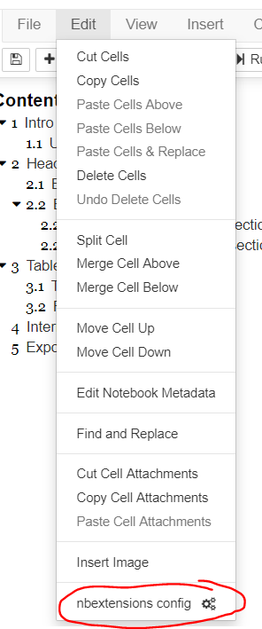

Recommended extensions to enable are:

- Codefolding, codefolding in editor
- RISE (for creating presentations)
- spellchecker (not as good as Word! Use proper spellcheck for customer deliverables)
- Table of Contents (2)
- Hide input
- Hide input all
- Export embedded html
- table_beautifier (this prints html tables)

## Numbering headings

The headings can be automatically numbered by following these steps:

- Enable Table of Contents (2) nbextension, following the instructions above
- Refresh the notebook
- To add a TOC side-bar, click the new button shown, which should have appeared in your notebook ribbon

Turn on the TOC sidebar

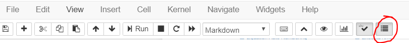

For additional formatting, you can edit the options.

- Check 'Skip h1 headings from numbering, so that they can serve as notebook title
- For Ricardo colours, change the options to:
  - Hover color in toc: HEX #C0C0C0 (Red 192, Green 192, Blue 192)
  - Color of highlight mark on scrolling: HEX #0070C0 (Red 0, Green 112, Blue 192)
  - Color of sections with selected elements: white
  - Color of sections with running cells: white

### Example heading - section

#### Example heading - subsection

## Tables and figures

### Tables

Use `style.set_caption` option within pandas to add numbered captions for tables. The formatting comes from the ricardo_stylesheet.css, which you need to enable in order to see the Ricardo colours and the automatic numbering.

As an example, you can run the following code to get the table output below:

```
import seaborn as sns
import pandas as pd
iris = sns.load_dataset('iris')
iris.head().style.set_caption('Example table')
```

Example table

|  | sepal_length | sepal_width | petal_length | petal_width | species |
| --- | --- | --- | --- | --- | --- |
| 0 | 5.1 | 3.5 | 1.4 | 0.2 | setosa |
| 1 | 4.9 | 3 | 1.4 | 0.2 | setosa |
| 2 | 4.7 | 3.2 | 1.3 | 0.2 | setosa |
| 3 | 4.6 | 3.1 | 1.5 | 0.2 | setosa |
| 4 | 5 | 3.6 | 1.4 | 0.2 | setosa |

The numbering should increment automatically (this also comes from the css file).

Example table

|  | sepal_length | sepal_width | petal_length | petal_width | species |
| --- | --- | --- | --- | --- | --- |
| 145 | 6.7 | 3 | 5.2 | 2.3 | virginica |
| 146 | 6.3 | 2.5 | 5 | 1.9 | virginica |
| 147 | 6.5 | 3 | 5.2 | 2 | virginica |
| 148 | 6.2 | 3.4 | 5.4 | 2.3 | virginica |
| 149 | 5.9 | 3 | 5.1 | 1.8 | virginica |

### Figures

Since we might use various packages to create figures, the captions are created using HTML tag `<figcaption>` and automatically numbered in the same way as for tables, using the ricardo_stylesheet.css file.

To display HTML from within a code cell, we need to wrap the tag in `display(HTML())` as shown below.

```
import matplotlib.pyplot as plt
%matplotlib inline
# Set styles
plt.style.use('seaborn-white')

display(HTML('<figcaption> Example figure - output showing </figcaption>'))
plt.scatter(iris['sepal_length'], iris['sepal_width'], alpha = 0.5)
```

Example figure - output showing

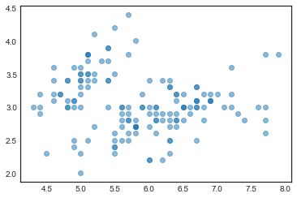

You may notice outputs like `[<matplotlib.lines.Line2D at 0x113c26898>]`. This is because Jupyter renders the return value of the function as well as the graphical output. You can suppress the value and only show the plot by appending `;` to a command:

```
display(HTML('<figcaption> Example figure - output hidden </figcaption>'))
plt.scatter(iris['sepal_length'], iris['sepal_width'], alpha = 0.5);
```

Example figure - output hidden

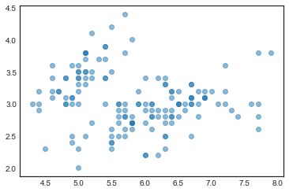

### Interactive plotting

#### Libraries

We recommend using Plotly and Cufflinks for interactive plotting.

- Plotly is an interactive plotting library
- Cufflinks binds Plotly to pandas dataframes

To get started, install the required packages

```
pip install plotly
pip install cufflinks
```

When using these libraries to plot offline in Jupyter Notebooks, there is an additional initialisation step needed. Run the following to set up the notebook:

```
import plotly.plotly as py
import plotly.graph_objs as go
from plotly.offline import iplot, init_notebook_mode, offline
init_notebook_mode(connected=True)

import cufflinks as cf
cf.set_config_file(offline=True,
                   world_readable=False,
                   theme='white')
```

The extra commands are to enable offline plotting within the notebook.

#### Cufflinks for simple plots

Create the graph below using the following commands:

```
display(HTML('<figcaption> Cufflinks graph - good for quick explorations </figcaption>'))
iris.iplot(x = 'sepal_length', y = 'sepal_width',
           kind = 'scatter', mode = 'markers', size = 8,
          color = 'blue')
```

Cufflinks allows for creation of most plot types within a single line. You can also see that the automatic caption numbering can be used with any plotting library

Cufflinks graph - good for quick explorations

[interactive chart not shown]

Cufflinks works well for most simple graphs and we recommend it for quick exploration. However, if you want to do more advanced customisations, you essentially need to access the underlying Plotly code - and depending on the amount of customisation you need, it might make sense to use Plotly directly.

You can view the available parameters by typing: `help(iris.iplot)`

**Tip:** If graphs are not displaying, check that the notebook is trusted.

Trust settings at the top right of the screen

[figure not shown]

#### Plotly for advanced interactive plots

For more advanced customisation, you may need to use Plotly itself. The interface is quite simple:

```
x = iris['sepal_length']
y = iris['sepal_width']
display(HTML('<figcaption> Plotly graph - better for customised finished graphs </figcaption>'))
fig = go.Figure()
fig.add_scatter(x=x,
                y=y,
                mode='markers',
                marker={'size': 10,
                        'opacity': 0.6,
                        'colorscale': 'Viridis'
                       });
iplot(fig)
```

Plotly graph - better for customised finished graphs

[interactive chart not shown]

**NB:** Since entering data into the Plotly format is cumbersome, for any serious project using interactive graphs, use loops and custom functions.  
*There is a separate tutorial on interactive plotting: 03_Simple_interactive_reports.html*

Plotly graphs can be customised endlessly. Key functions to be aware of are:

- Visible: to determine if a trace is visible or not. Use it to hide or show different chart elements
- Hoverinfo: Customise the information shown on mouse hover. The defaults are to show everything, which quickly becomes cluttered.
- Hoverlabel: Customise the look of the labels

## Internal comments

Several built-in styles are provided to make commenting easier. These can be rendered in Markdown cells or in code.

Example code:

```
display(HTML('''<div class = 'todo'>
    Note: Things to do.
</div>'''))
```

Note: Things to do.

You have several built-in options from the css file, which give different colours. You can access these by changing the class to different options:

- todo (red)
- commenter1 (yellow)
- commenter2 (blue)
- commenter3 (purple)

Comments class 'commenter1'

Comments class 'commenter2'

Comments class 'commenter3'

## Exporting to different formats

### HTML

Use the command below to export the notebook to HTML while retaining the table of contents (save the notebook first).

```
jupyter nbconvert 01_Ricardo_template_example.ipynb --template toc2
```

You need to navigate to your project folder in terminal and run the command there.

In the current version of the extension, the colour scheme for the TOC does not update when exporting to HTML and it returns to the default settings. This seems to be a bug in the extension template file itself and may be fixed in later versions.

Alternatively, you can save the file as html by choosing file>download as>.html embedded. This will not bring the table of contents across. Exporting regular html will not include embedded pictures - you need to have the embedded html option enabled.

### PDF

The built-in functions to save to PDF require pandoc and MikTeX installations, and tend to produce formatting errors.

The best way to get a PDF is:

1. Save to HTML using either of the following code

   ```
   # To keep code visibility
   jupyter nbconvert --to html notebook.ipynb
   # To hide all code
   jupyter nbconvert --template=nbextensions --to=html notebook.ipynb
   ```

**For a simple check:**

1. Open the HTML file in your browser
2. Ctrl + P to print
3. Choose save as PDF
4. Choose More settings > untick headers and footers

This will "print what you see", so ensure the HTML file looks just as you want it. You will not see the numbered headings, as these come from the TOC2 extension and this won't be exported. There will also probably be strange page breaks as it tries not to split cells across pages.

**For a more professional look:**

1. The best free service I've found is: https://www.sejda.com/html-to-pdf, which picks up the table of contents and generally seems able to handle complex formatting. If you find a better one, let me know.
2. However, it's limited to 50MB, so not suitable for very large files.

**It is best not to offer PDF versions of a HTML report as a final deliverable**, since they will not have the functionality or looks we have come to expect from converting Word docs.  
Find out early from the client if this is what they want - if it is, a better way of compiling the report may be to export the graphics as PNG files and embed them into a Word document, much as we would for a normal report.

### Single files

**Static plots**

You can export static plots using the following command:

```
plt.savefig('name.png')
```

These can be embedded into Word and Powerpoint just like any other picture and they look great.

**Interactive plots**

You can export interactive plots:

```
from plotly.offline import offline
offline.plot(fig, filename='name.html')
```

These can be embedded in other deliverables such as powerpoints or Word docs, but need to be viewed in a browser.

**csv files**

Once you have your analysis in a dataframe, you can save it to a csv file:

```
dataframe.to_csv('name.csv')
```

### Data protection and security risks

Clients may ask if html reports are "secure". This is something you should discuss with them right at the start of the project.

**The data is stored in the HTML file itself and will not be secure.** The data will be relatively easy to access and change.  
If the client wants to publish the HTML file but the data is sensitive, this is an obvious no-go  
If the client wishes to have a confidential HTML report, we need to be mindful of how we share the files and use secure systems.

However, data security is not typically an issue for many of our clients, since they are public reports and the underlying data should be accessible anyway.

If the client is concerned about this, you should deliver the report without interactive elements. The analysis can still be done in Notebooks, which we do encourage for repeatability and clarity. It is even possible to write the outputs and any charts into an Excel file if that is what the client prefers.

If the client is concerned about "security risks" rather than data security, this is not a problem. If you are sending a html report to customer, its the same as sending a word file or a pdf.

## Hiding code

### Hide all code in a notebook

If you know you want to hide all of the code, the best way to do this is using the `hide code all` extension. This allows you to preview how the notebook will look while still using Jupyter.

- Select the hide code icon in the ribbon (see figure below).
- You can toggle this on and off while you are working in the Notebook.
- If you want to export the notebook with the code still hidden **save the notebook after suppressing the code cells** and then export it using the standard html conversion command `jupyter nbconvert 01_Ricardo_template_example.ipynb --template toc2`.

Hide all code cells

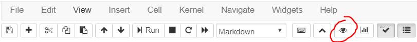

### Hiding individual cells

Using the hide code button is the best way to remove all of the code in a notebook. You can also hide individual cells using the ^ button. Remember that you have to save the notebook before converting it to html in order to preserve the view.

However, the individually hidden code cells will all revert to being visible next time you open the notebook. So, if you want to mix hidden and visible code in your deliverable, the best way is to edit the cell metadata. This preserves the hidden and showing cells between sessions.

To do this:

1. go to View > Cell Toolbar > Edit Metadata
2. click the Edit Metadata button now showing to the top right of the cell
3. add 'hide_input': true to the JSON
4. click edit to save
5. convert to html using `jupyter nbconvert 01_Ricardo_template_example.ipynb --template toc2`

You should pick one method or the other, but don't try to mix them as the hide commands from the extension and nbconvert can cancel out.

Turn on the metadata toolbar

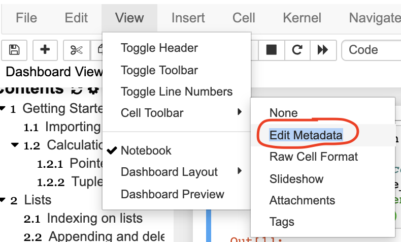

Edit Metadata button will now appear

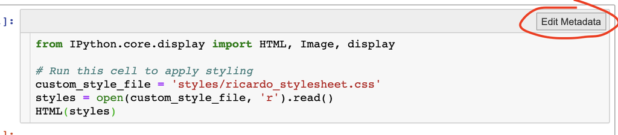

Edit the JSON

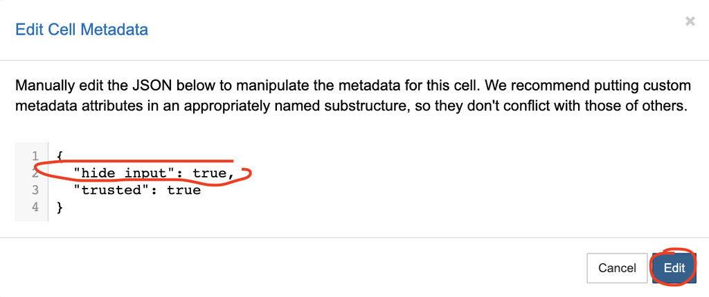

## Troubleshooting

**Header formatting**

- Numbers aren't showing in the notebook: have you enabled TOC2 extension?
- Numbers aren't showing when exporting to html: are you using the specific export commands that are specified above?

**Extensions**

- XXX extension is missing or not working: If any of the extensions aren't showing or don't seem to be working, try closing Jupyter down completely, including the terminal. You can also try running the activation command again: `jupyter contrib nbextension install --user`

**Exporting problems**

- Have you saved the notebook with the final view that you want first?
- Are you using the specific export commands given above?
- Is the stylesheet enabled?

**Still having problems?**

- Ask Gena

Please contact gena.gibson@ricardo.com with any suggestions  
Version last updated on 27 June 2019